# Berkeley Crime Data

Let's take a look at some crime data from Berkeley, Ca! I started this notebook for some basic data exploration and to gain some experience with GeoPandas. That evolved into trying to see if I could use a Random Forest Classifier to predict crimes in Berkeley. Throughout this notebook I'll provide some interesting insights into where certain crimes occur in Berkeley and places to be extra cautious when parking your car.

The data used in this analysis comes from https://data.cityofberkeley.info/browse, which has a variety publicly available data for Berkeley (including where trees major trees are located in the city). I highly recommend checking it out if you're looking for some data to work on.

To run this notebook you'll need Berkeley block group maps (downloaded as shapefiles) and the most recent Berkeley-PD calls for services as a csv.

```python
import numpy as np
import pylab as plt

import geopandas
import fiona  # for reading in shapefiles
import pandas as pd
import seaborn as sns
from sklearn.metrics import log_loss, confusion_matrix
from sklearn.linear_model import LogisticRegression
from sklearn.ensemble import RandomForestClassifier
from sklearn import preprocessing
import seaborn as sns
from shapely.geometry import Point, Polygon  # we'll need this for playing with geometry shapfiles
color = sns.color_palette()

%matplotlib inline
```

Let's start off by reading in the police data using pandas (I downloaded the data as a csv so we can use the read_csv function). Additionally, I am also renaming the columns to have sane names and breaking out the lat and long into it's own column. The lat and long is being saved as a shapely Point geometry. This will be helpful once we define a geopandas dataframe.

```python
crime_data = pd.read_csv('Berkeley_PD_-_Calls_for_Service.csv')

def get_point(loc_str):
    try:
        lat, lng = map(float, loc_str.split('\n')[-1][1:-2].split(','))
        return Point(lng, lat)
    except ValueError:
        return Point([-1,-1])

crime_data.rename(columns={'CASENO':'Case Number',
                           'OFFENSE': 'Offense',
                           'EVENTDT': 'Event Date',
                           'EVENTTM': 'Event Time',
                           'CVLEGEND': 'Crime Legend',
                           'CVDOW':'Day of Week',
                           'InDbDate':'Database Date',
                           'Block_Location': 'Location',
                           'BLKADDR': 'Block Address'}, inplace=True)

crime_data['Coord'] = crime_data['Location'].map(get_point)
crime_data = crime_data.drop('Location', axis=1)

crime_data.head(5)
```

|  | Case Number | Offense | Event Date | Event Time | Crime Legend | Day of Week | Database Date | Block Address | City | State | Coord |
| --- | --- | --- | --- | --- | --- | --- | --- | --- | --- | --- | --- |
| 0 | 17039995 | BURGLARY AUTO | 07/10/2017 12:00:00 AM | 11:15 | BURGLARY - VEHICLE | 1 | 09/12/2017 03:30:17 AM | 1900 SAN PABLO AVE | Berkeley | CA | POINT (-122.29259 37.870236) |
| 1 | 17028778 | VEHICLE STOLEN | 05/20/2017 12:00:00 AM | 22:00 | MOTOR VEHICLE THEFT | 6 | 09/12/2017 03:30:15 AM | 1400 DWIGHT WAY | Berkeley | CA | POINT (-122.28302 37.86194) |
| 2 | 17091329 | BURGLARY AUTO | 07/10/2017 12:00:00 AM | 20:40 | BURGLARY - VEHICLE | 1 | 09/12/2017 03:30:17 AM | 1300 TENTH ST | Berkeley | CA | POINT (-122.29689 37.879996) |
| 3 | 17032777 | ROBBERY | 06/08/2017 12:00:00 AM | 01:13 | ROBBERY | 4 | 09/12/2017 03:30:16 AM | SHATTUCK AVENUE & CENTER ST | Berkeley | CA | POINT (-122.268 37.870308) |
| 4 | 17033981 | BURGLARY AUTO | 06/13/2017 12:00:00 AM | 15:40 | BURGLARY - VEHICLE | 2 | 09/12/2017 03:30:17 AM | 2400 DURANT AVE | Berkeley | CA | POINT (-122.2612 37.867513) |

## Some Views on the Data

Now that we have our data frame with sane columns and all the information we might want. Let's do some basic exploratory work! Let's get some basic stats like how many total calls and how many in each category etc...

```
There were 5520 crimes
```

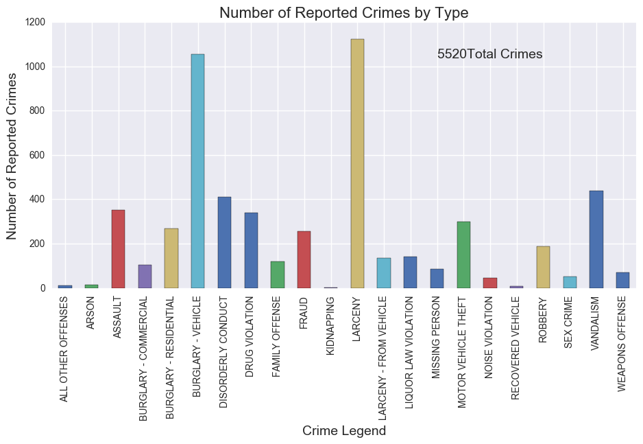

```python
print 'There were {0} crimes'.format(len(crime_data))
# get the number of crimes per type
group_by_legend = crime_data.groupby('Crime Legend')
ax = group_by_legend.size().plot(kind='bar', figsize=(11,5))
ax.text(14, 1040, str(len(crime_data)) + 'Total Crimes', fontsize=14)
ax.set_ylabel('Number of Reported Crimes', fontsize=14)
ax.set_xlabel('Crime Legend', fontsize=14)
ax.set_title('Number of Reported Crimes by Type', fontsize=16)
```

So it looks like most of the crimes are burglary's or larceny's (larceny is taking something from another person or business and burglary is the unlawful breaking into a location with the purpose of commiting an offense).

How does crime track over time?

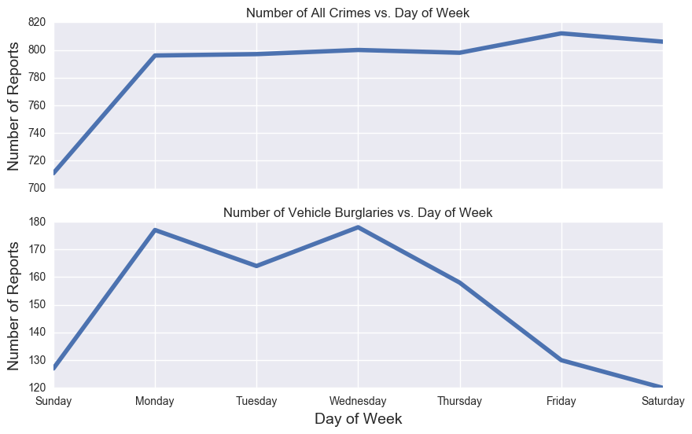

```python
car_burgs = group_by_legend.get_group('BURGLARY - VEHICLE').copy()

plt.figure(figsize=(10,6))

plt.subplot(212)
ax1 = car_burgs.groupby('Day of Week').size().plot(lw=4)
ax1.set_xticklabels(['Sunday', 'Monday', 'Tuesday', 'Wednesday', 'Thursday', 'Friday', 'Saturday'])
ax1.set_ylabel('Number of Reports', fontsize=14)
ax1.set_xlabel('Day of Week', fontsize=14)
ax1.set_title('Number of Vehicle Burglaries vs. Day of Week')

plt.subplot(211, sharex=ax1)
ax2 = crime_data.groupby('Day of Week').size().plot(lw=4)
ax2.set_ylabel('Number of Reports', fontsize=14)
ax2.set_title('Number of All Crimes vs. Day of Week')
```

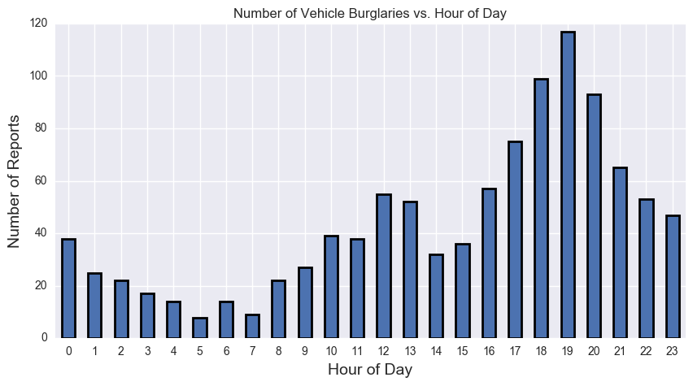

```python
car_burgs['Hour'] = car_burgs['Event Time'].apply(lambda x: int(x.split(':')[0]))

color = ax1.lines[0].get_color()
ax1 = car_burgs.groupby('Hour').size().plot(lw=2, kind='bar', color=color, figsize=(10,5))
ax1.set_ylabel('Number of Reports', fontsize=14)
ax1.set_xlabel('Hour of Day', fontsize=14)
ax1.set_title('Number of Vehicle Burglaries vs. Hour of Day')
ax1.xaxis.set_ticklabels(range(24), rotation=0);
```

Crimes are going to happen any day of the week, with about a 10% less chance of occurring on Sundays (overall). However, Looking specifically at Vehicular Burglaries, there is a significantly larger chance (almost 50%) that your car is going to be broken into and something stolen during the week, and specifically Monday - Thursday.

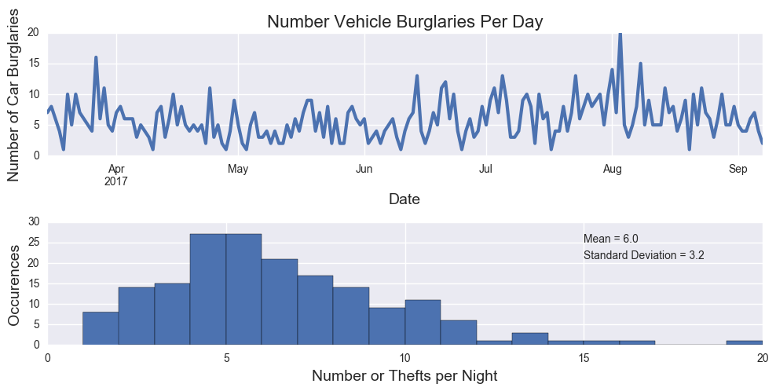

```python
car_burgs['DateTime'] = pd.to_datetime(car_burgs['Event Date'])
car_burgs_by_date = car_burgs.groupby('DateTime')
average = car_burgs_by_date.size().mean()
std = car_burgs_by_date.size().std()


plt.figure(figsize=(10,5))

plt.subplot(211)
ax = car_burgs_by_date.size().plot(kind='line', lw=3)
ax.set_ylabel('Number of Car Burglaries', fontsize=14)
ax.set_xlabel('Date', fontsize=14)
ax.set_title('Number Vehicle Burglaries Per Day', fontsize=16)

plt.subplot(212)
ax1 = car_burgs_by_date.size().hist(bins=19)
ax1.set_ylabel('Occurences', fontsize=14)
ax1.set_xlabel('Number or Thefts per Night', fontsize=14)
ax1.text(15, 25, 'Mean = {0:1.1f}'.format(average))
ax1.text(15, 21, 'Standard Deviation = {0:1.1f}'.format(std))

plt.tight_layout()
```

The number of vehicle burglaries every night looks like it may follow a Poisson distribution. The maximum (20 events in a day) is an almost 5 sigma outlier, and therefore I consider it an anomoly. There also seems to be a weekly trend, but not many outliers except for in the first week of August (probably because new students come to settle in).

Now that we have shown some general trends in time for when car burglaries occur, let's now try to figure out where these actually take place.

## Where are car burglaries more likely to happen in Berkeley?

Let's now plot these car burglaries on the map of Berkeley. To do this we use Geopandas. First we've instantiated a GeoDataFrame with the crime_data panadas DataFram from above. We need to tell the GeoDataFrame which column contains the Geo data (geometry). This is why we created the Point geometries for the crimes using their lat and long.

We can also read in the shapefiles that have the polygons describing the boundaries of block groups.

One last note: Every GeoDataFrame needs to have a Coordinate Reference System (crs) set. There are thousands of these but the moset comonly used one is epsg:4326.

```
(37.84, 37.91)
```

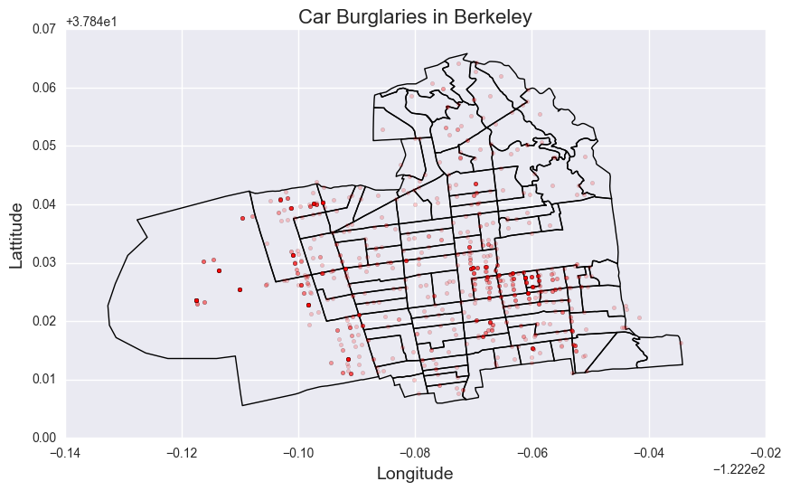

```python
# geo_crime_data = geopandas.GeoDataFrame(crime_data, geometry='Coord')
geo_crime_data = geopandas.GeoDataFrame(car_burgs, geometry='Coord')
geo_crime_data.crs = {'init': 'epsg:4326'}
geo_crime_data = geo_crime_data[geo_crime_data.Coord != Point(-1,-1)]

berkeley = geopandas.read_file('Census Block Group Polygons 2010/geo_export_c2d6150e-03a5-4b10-a7e1-72d684674105.shp')
berkeley.crs = {'init': 'epsg:4326'}

fig, ax = plt.subplots(1, figsize=(10,10))
ax.set_aspect('equal')
berkeley_map = berkeley.plot(ax=ax, color='none', lw=1)
geo_crime_data.plot(ax=berkeley_map, marker="o", markersize=10, color='red', alpha=0.2, edgecolor='black')
berkeley_map.set_ylabel('Lattitude', fontsize=14)
berkeley_map.set_xlabel('Longitude', fontsize=14)
berkeley_map.set_title('Car Burglaries in Berkeley', fontsize=16)
plt.ylim(37.84, 37.91)
```

This just shows the boundaries of Berkeley neighborhoods and all of the burglaries as red dots. Let's take a look and see what neighborhoods have the most car burgularies by looking at the burglary per area. If you look at just the number of burgularies in a given neighborhood, we get skewed toward larger neighborhoods (i.e. down by Berkeley marina on the left side of the plot).

To do this, we join the geo_crime_data and Berkeley tables with a left join and then count the number of incidents. Then do a dataframe merge with the Berkeley dataframe (which joins on blkgrpce10). We then create a new column of crime_density and plot using the handy geopandas plot function!

```python
combined = geopandas.tools.sjoin(geo_crime_data, berkeley, how='left')

neighborhood_counts = combined.groupby('blkgrpce10')['Case Number'].count().reset_index()
neighborhood_counts.columns = ['blkgrpce10', 'num_incidents']
neighborhood_counts = neighborhood_counts.sort_values(by='num_incidents', ascending=False)
```

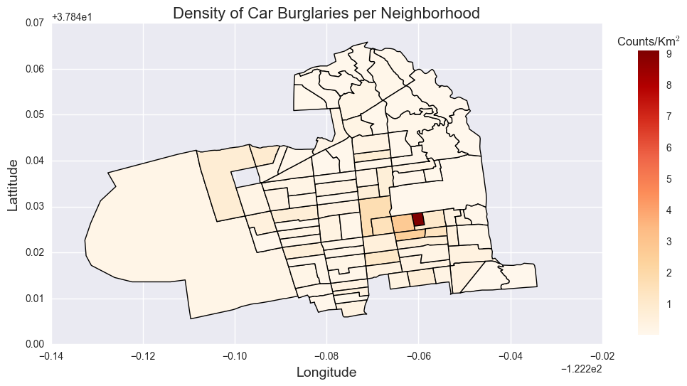

```python
chloroleth_data = neighborhood_counts.merge(berkeley)
chloroleth_data = geopandas.GeoDataFrame(chloroleth_data, geometry='geometry')
chloroleth_data.crs = {'init': 'epsg:4326'}
chloroleth_data.to_crs({'init': 'epsg:3857'})# convert coordinate system to get area in km^2


chloroleth_data['crime_density'] = chloroleth_data['num_incidents']/chloroleth_data['geometry'].area/1e6

chloroleth_data.crs = {'init': 'epsg:4326'} # convert back for plotting

ax = chloroleth_data.plot(column='crime_density', cmap='OrRd', figsize=(10,10), lw=1)
ax.set_ylabel('Lattitude', fontsize=14)
ax.set_xlabel('Longitude', fontsize=14)
ax.set_title('Density of Car Burglaries per Neighborhood', fontsize=16)
plt.ylim(37.84, 37.91)

fig = ax.get_figure()
cax = fig.add_axes([0.95, 0.3, 0.03, 0.4])
cax.set_title(r'Counts/Km$^{2}$')
sm = plt.cm.ScalarMappable(cmap='OrRd', norm=plt.Normalize(vmin=np.min(chloroleth_data['crime_density']), vmax=np.max(chloroleth_data['crime_density'])))
# fake up the array of the scalar mappable.
sm._A = []
fig.colorbar(sm, cax=cax)
```

Most of the car thefts happen on the south side of the UC campus and in Downtown Berkeley. Also, the neighborhoods on the south side of university ave. have a higher car burgulary rate than the north side.

## Can we predict crimes?

Now that we have some familiarity with the data, let's put this data to good use and try to predict crimes. Specifically, the question I want to ask is, "can I predict what type of crime is going to occur given the date, time, and location of the crime?" This is a classic classification prediction problem.

Berkeley only offers data for the past 6 months, and I initially downloaded data back in October, but recently downloaded a newer data set that doesn't overlap. This gives us roughly a year of data.

```python
pds = [pd.read_csv(file) for file in ['Berkeley_PD_-_Calls_for_Service.csv', '/Users/sherlock/Downloads/Berkeley_PD_-_Calls_for_Service.csv']]
new_crime_data = pd.concat(pds, ignore_index=True)

def get_point(loc_str):
    try:
        lat, lng = map(float, loc_str.split('\n')[-1][1:-2].split(','))
        return Point(lng, lat)
    except ValueError:
        return Point([-1,-1])

new_crime_data.rename(columns={'CASENO':'Case Number',
                               'OFFENSE': 'Offense',
                               'EVENTDT': 'Event Date',
                               'EVENTTM': 'Event Time',
                               'CVLEGEND': 'Crime Legend',
                               'CVDOW':'Day of Week',
                               'InDbDate':'Database Date',
                               'Block_Location': 'Location',
                               'BLKADDR': 'Block Address'}, inplace=True)

new_crime_data['Coord'] = new_crime_data['Location'].map(get_point)
new_crime_data = new_crime_data.drop('Location', axis=1)
```

```python
new_crime_data.head(2)
```

|  | Case Number | Offense | Event Date | Event Time | Crime Legend | Day of Week | Database Date | Block Address | City | State | Coord |
| --- | --- | --- | --- | --- | --- | --- | --- | --- | --- | --- | --- |
| 0 | 17039995 | BURGLARY AUTO | 07/10/2017 12:00:00 AM | 11:15 | BURGLARY - VEHICLE | 1 | 09/12/2017 03:30:17 AM | 1900 SAN PABLO AVE | Berkeley | CA | POINT (-122.29259 37.870236) |
| 1 | 17028778 | VEHICLE STOLEN | 05/20/2017 12:00:00 AM | 22:00 | MOTOR VEHICLE THEFT | 6 | 09/12/2017 03:30:15 AM | 1400 DWIGHT WAY | Berkeley | CA | POINT (-122.28302 37.86194) |

### Making Features

Let's organize our data and make some features. There's a number of data reductions we need to do.

1. First we need to build up our classes. We'll categorize the 'Crime Legend' column and will be our targets for our classification algorithm. Looking at the data below, I noticed that there were some categories which only had a handful of reports and thus the distribution into the training, validation, and test set are hard to get evenly. We'll remove those low number crimes (< 10) to get a better distribution. This has the draw back of never being able to classify those crimes with future data.
2. Next, we need to figure out what are the features we are going to use. I'll build a model using the data we have. Specifically, we'll use location data (lat, long), the day of the week, and the date and time of the crime. I'll additionally engineer some features from this indicating if the date is a weekend or a weekday.
3. Finally, we need to decide what type of classifier we are going to use. For this exercise, I'll use logistic regression as the base model and then use a random forest classifier to see if we can do better.

```python
# remove crime types that are fewer than 10 in number.
new_crime_data = new_crime_data.groupby('Crime Legend').filter(lambda x: x['City'].count() > 10, dropna=True)
new_crime_data = new_crime_data.reset_index(drop=True)

# get classes of crimes from Crime Legend
classes = list(new_crime_data['Crime Legend'].unique())

# create an empty data frame for features
feature_df = pd.DataFrame()

# getting the date and time of each crime
d = new_crime_data['Event Date'].map(lambda x: x.split(' ')[0])
t = new_crime_data['Event Time']

feature_df['dtime'] = pd.to_datetime(d, format='%m/%d/%Y')
feature_df['time'] = pd.to_datetime(t)
# fix time in datetime object and drop time column
feature_df['dtime'] = feature_df.apply(lambda x: x.dtime.replace(hour=x.time.hour, minute=x.time.minute), axis=1)
feature_df.drop('time', axis=1, inplace=True)

# add in coordinates
feature_df['long'] = new_crime_data['Coord'].apply(lambda x: x.coords[0][0])
feature_df['lat'] = new_crime_data['Coord'].apply(lambda x: x.coords[0][1])

# drop rows with bad location data. These have lat,long = -1.0
drop_indexes = np.where(feature_df['long'] == -1.0)[0]
feature_df = feature_df.drop(drop_indexes)

# label the crimes
feature_df['labels'] = new_crime_data['Crime Legend'].apply(lambda x: classes.index(x))
```

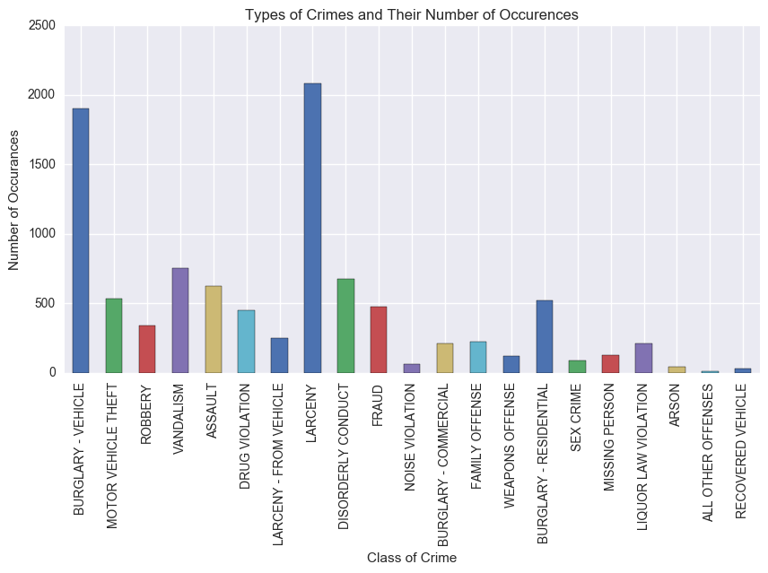

```python
# check how the labels are distributed. Same plot as before and a sanity check.
ax = feature_df.groupby('labels').count()['dtime'].plot(kind='bar', figsize=(10,5))
ax.set_xticklabels(classes);
ax.set_xlabel('Class of Crime')
ax.set_ylabel('Number of Occurances')
ax.set_title('Types of Crimes and Their Number of Occurences')
```

Now lets make the features from the date and time objects.

```python
# make features...specifically make day of week, month number, hour of crime, and if day was a weekend features.
feature_df['dow'] = feature_df.dtime.map(lambda x: x.dayofweek)
feature_df['month'] = feature_df.dtime.map(lambda x: x.month)
feature_df['hour'] = feature_df.dtime.map(lambda x: x.hour)
feature_df['weekend'] = feature_df.dtime.map(lambda x: int(x.isoweekday() in [6,7]))
feature_df.drop(labels=['dtime'], axis=1, inplace=True)

# get labels as stand alone matrix
Ylabels = feature_df['labels'].as_matrix()
# make feature matrix so we can use scikit learn
feature_matrix = feature_df.as_matrix()
# delete repeated column
features = np.delete(feature_matrix, 2, 1)
ll = preprocessing.LabelEncoder()
crimes = ll.fit_transform(feature_df['labels'])
```

```python
# create a 60/20/20 split of data into train, validate, and test set
N = len(Ylabels)
sample_indexes = range(N)
np.random.shuffle(sample_indexes)

# fractions of data for train, val, test
train_frac = int(N*.6)
val_frac = int(N*.2)

# slice out random samples of data
X_train = features[sample_indexes[:train_frac]]
Y_train = Ylabels[sample_indexes[:train_frac]]

X_val = features[sample_indexes[train_frac:train_frac+val_frac]]
Y_val = Ylabels[sample_indexes[train_frac:train_frac+val_frac]]

X_test = features[sample_indexes[train_frac+val_frac:]]
Y_test = Ylabels[sample_indexes[train_frac+val_frac:]]

print('Train set has {0} data points'.format(len(Y_train)))
print('Validation set  has {0} data points'.format(len(Y_val)))
print('Test set has {0} data points'.format(len(Y_test)))
```

```
Train set has 5838 data points
Validation set  has 1946 data points
Test set has 1946 data points
```

## Logistic Regression

We'll start off by using logistic regression. Logistic regression is the standard classification algorithm that is often use as the base model that all other models are compared too. We will take this route here and look at how well we are doing.

```python
clf_logit = LogisticRegression()
clf_logit.fit(X_train, Y_train);
print("Logistic Regression has accuracy {0}".format(np.mean(clf_logit.predict(X_val) == Y_val)))
```

```
Logistic Regression has accuracy 0.224563206578
```

Now we can tune some logistic regression parameters to tweak this model to work best on the validation set. We'll tune the regularization scalar and the type of regularization (either L1 or L2).

```python
Cs = [.01, .03, .1, .3, 1., 10] # create list of inverse regularization strengths
logit_models = {}
for _C in Cs:
    for norm in ['l1', 'l2']:
        clf_logit = LogisticRegression(C=_C, penalty=norm)
        clf_logit.fit(X_train, Y_train);
        logit_models[norm,_C] = clf_logit
        print("Logistic Regression with {0} norm and C={1} has accuracy={2}, log loss={3} ".format(norm, _C, np.mean(clf_logit.predict(X_val) == Y_val), log_loss(Y_val, clf_logit.predict_proba(X_val))))
```

```
Logistic Regression with l1 norm and C=0.01 has accuracy=0.235354573484, log loss=2.52332807909
Logistic Regression with l2 norm and C=0.01 has accuracy=0.226104830421, log loss=2.51490808533
Logistic Regression with l1 norm and C=0.03 has accuracy=0.229701952724, log loss=2.51667548394
Logistic Regression with l2 norm and C=0.03 has accuracy=0.225590955807, log loss=2.5145074586
Logistic Regression with l1 norm and C=0.1 has accuracy=0.226104830421, log loss=2.51453366754
Logistic Regression with l2 norm and C=0.1 has accuracy=0.226104830421, log loss=2.51444600651
Logistic Regression with l1 norm and C=0.3 has accuracy=0.226104830421, log loss=2.51390370435
Logistic Regression with l2 norm and C=0.3 has accuracy=0.225590955807, log loss=2.51460417922
Logistic Regression with l1 norm and C=1.0 has accuracy=0.225590955807, log loss=2.51436759196
Logistic Regression with l2 norm and C=1.0 has accuracy=0.224563206578, log loss=2.51480871327
Logistic Regression with l1 norm and C=10 has accuracy=0.225077081192, log loss=2.51504152989
Logistic Regression with l2 norm and C=10 has accuracy=0.225077081192, log loss=2.51511152665
```

So we've established our base model and we're getting around ~23% accuracy on the validation set and the log loss bottoms out at 2.5. This is also with essentially the defaults out of scikit-learn. Let's keep this in mind as our base accuracy and log loss.

Let's try another model now. I'll use a RandomForest classifier to classify the data. Since we have features that are on different scales (for example binary features and the coordinates of the crime) and since we haven't done any feature normalization, RF is the best bet for a better multiclass classification algorithm. It is also less suceptable to over fitting since it uses ensemble methods.

## Random Forest

Let's see if we can do better with a random forest classifier. I'm using scikit-learns defaults for RandomForest with 4 trees in the forest as my base. We'll then optimze and tune parameters. I am choosing to optimize 2 parameters, the number of trees in a forest and the minimum sample for leafs. The minimum leaf size is the number of samples that end a tree.

```python
clf_rf = RandomForestClassifier(n_estimators=4)
clf_rf.fit(X_train, Y_train);
print("Random Forest has accuracy={0}, log loss={1} ".format(np.mean(clf_rf.predict(X_val) == Y_val), log_loss(Y_val, clf_rf.predict_proba(X_val))))

# optimizing
n_estimators = [4, 20, 50, 100, 500, 1000]
min_sample_leafs = [1, 10, 50, 100]
models = {}
for n_estimator in n_estimators:
    for msl in min_sample_leafs:
        _clf_rf = RandomForestClassifier(n_estimators=n_estimator, min_samples_leaf=msl)
        _clf_rf.fit(X_train, Y_train)
        models[(n_estimator, msl)] = _clf_rf
        print("Random Forest with {0} estimators and msl={1} has accuracy={2}, log loss={3} ".format(n_estimator, msl, np.mean(_clf_rf.predict(X_val) == Y_val), log_loss(Y_val, _clf_rf.predict_proba(X_val))))
```

```
Random Forest has accuracy=0.208119218911, log loss=20.3502889925
Random Forest with 4 estimators and msl=1 has accuracy=0.215313463515, log loss=20.406462543
Random Forest with 4 estimators and msl=10 has accuracy=0.254367934224, log loss=4.55470602038
Random Forest with 4 estimators and msl=50 has accuracy=0.270298047276, log loss=2.66150329852
Random Forest with 4 estimators and msl=100 has accuracy=0.267214799589, log loss=2.5254373896
Random Forest with 20 estimators and msl=1 has accuracy=0.249229188078, log loss=10.5260884695
Random Forest with 20 estimators and msl=10 has accuracy=0.284686536485, log loss=2.69638765888
Random Forest with 20 estimators and msl=50 has accuracy=0.27183967112, log loss=2.41302787868
Random Forest with 20 estimators and msl=100 has accuracy=0.268242548818, log loss=2.42074545167
Random Forest with 50 estimators and msl=1 has accuracy=0.258992805755, log loss=6.9259431133
Random Forest with 50 estimators and msl=10 has accuracy=0.289825282631, log loss=2.48633157365
Random Forest with 50 estimators and msl=50 has accuracy=0.268756423433, log loss=2.39385936161
Random Forest with 50 estimators and msl=100 has accuracy=0.265159301131, log loss=2.41018304277
Random Forest with 100 estimators and msl=1 has accuracy=0.255395683453, log loss=5.0212224313
Random Forest with 100 estimators and msl=10 has accuracy=0.289825282631, log loss=2.37251305127
Random Forest with 100 estimators and msl=50 has accuracy=0.273381294964, log loss=2.38741616369
Random Forest with 100 estimators and msl=100 has accuracy=0.26618705036, log loss=2.41263868193
Random Forest with 500 estimators and msl=1 has accuracy=0.264645426516, log loss=3.2412435093
Random Forest with 500 estimators and msl=10 has accuracy=0.29085303186, log loss=2.36134193812
Random Forest with 500 estimators and msl=50 has accuracy=0.270811921891, log loss=2.38773821791
Random Forest with 500 estimators and msl=100 has accuracy=0.265673175745, log loss=2.41165648762
Random Forest with 1000 estimators and msl=1 has accuracy=0.268756423433, log loss=2.95395417167
Random Forest with 1000 estimators and msl=10 has accuracy=0.291366906475, log loss=2.35605585151
Random Forest with 1000 estimators and msl=50 has accuracy=0.269784172662, log loss=2.38644815561
Random Forest with 1000 estimators and msl=100 has accuracy=0.265673175745, log loss=2.41072878215
```

```python
best_rf = models[1000,10]
base_logit = logit_models['l1', .03]
```

## The Test Set!

Now that we have optimized our parameters it is now time to see how well our models stack up to the test set.

```python
test_logit_accuracy = np.mean(base_logit.predict(X_test) == Y_test)
test_rf_accuracy = np.mean(best_rf.predict(X_test) == Y_test)

print("Logistic Regression Test Accuracy = {0}".format(test_logit_accuracy))
print("Random Forest Test Accuracy = {0}".format(test_rf_accuracy))
```

```
Logistic Regression Test Accuracy = 0.241521068859
Random Forest Test Accuracy = 0.290339157246
```

## Some Metrics

### The Confusion Matrix

The confusion matrix can be an informative plot for a classification algorithms. It shows the false positives and negatives that are classified by the classifier.

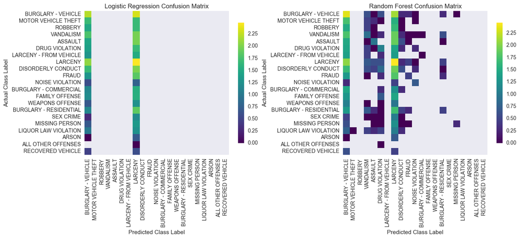

```python
from sklearn.metrics import confusion_matrix

plt.figure(1, figsize=(14,7))
plt.subplot(121)
plt.imshow(np.log10(confusion_matrix(Y_test, base_logit.predict(X_test))), interpolation='nearest', cmap='viridis'); plt.colorbar(shrink=.6)
ax = plt.gca()
ax.xaxis.set_ticks(range(len(classes)))
ax.xaxis.set_ticklabels(classes, rotation=90)
ax.yaxis.set_ticks(range(len(classes)))
ax.yaxis.set_ticklabels(classes, rotation=0)
plt.title('Logistic Regression Confusion Matrix')
plt.xlabel('Predicted Class Label')
plt.ylabel('Actual Class Label')
plt.grid(0)

plt.subplot(122)
plt.imshow(np.log10(confusion_matrix(Y_test, best_rf.predict(X_test))), interpolation='nearest', cmap='viridis'); plt.colorbar(shrink=.6)
ax = plt.gca()
ax.xaxis.set_ticks(range(len(classes)))
ax.xaxis.set_ticklabels(classes, rotation=90)
ax.yaxis.set_ticks(range(len(classes)))
ax.yaxis.set_ticklabels(classes, rotation=0)
plt.title('Random Forest Confusion Matrix')
plt.xlabel('Predicted Class Label')
plt.ylabel('Actual Class Label')
plt.grid(0)

plt.tight_layout()
```

From the confusion matrix we see that the logistic regression classifier is only predicting data as a vehicle burglary or a larceny, the two most dominant reported crimes. Logistic regression does not have enough flexibility to determine the complex classification space. On the other hand, random forest does slightly better, but it is still classifying reports based on the most reported crimes. At least, it didn't turn into a binary classifier.

### Feature Importance

Below we look at the feature importance as viewed by the random forest classifier. The most important features are the location of the crime, indicating that certain crimes are clustered around a given area (car thefts?), and the hour of day was third most important. The fact that a day was a weekend or not didn't really seem to matter.

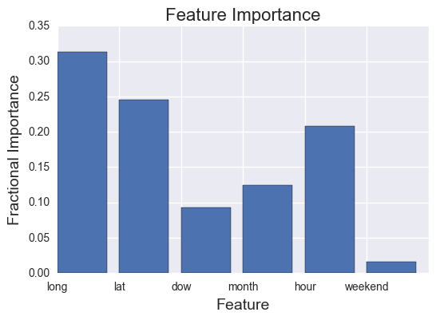

```python
# the most important features
feature_labels = list(feature_df.columns)
feature_labels.remove('labels')
plt.bar(range(6), best_rf.feature_importances_)
ax = plt.gca()
ax.xaxis.set_ticklabels(feature_labels)
ax.set_title('Feature Importance', fontsize=16)
ax.set_ylabel('Fractional Importance', fontsize=14)
ax.set_xlabel('Feature', fontsize=14)
```

# Summary

To summarize, I have explored crime data from the Berekely Data website. Using Geopandas I was able to show where in Berkeley the highest density of car thefts are and then took a look at if I could predict crimes using the data set. Using the data at hand, I used feature engineering to take the simple timestamp and coordinate of the crime to create meaningful features like what month, day of the week, and hour the crime took place. Training both a simple logistic regression and random forest model, I found that the random forest model is around 29% accurate on determining what type of crime is going to occur given the time and place of the event.

It is clear that more data is needed in order to build a better model of crime classification in Berkeley. Specifically, more diverse data is probably required such as specifics from the crime report (what was stolen, where was it, how loud, etc...). Then using natural language processing, there is potential to refine models.

Additionally, we can use the data in a different way. Instead of trying to predict the type of crime, we could try to answer a more practical question. This question would be to make build a model such that given a time, a location, and other tbd features, the probability that your car would be broken into. This question is a little more practical in the sense that there is a useful deliverable.

However, the types of models built here highlight that certain areas are prone to crime and help police departments distribute resources given the time of day and location.It can help provide information to where certain types of crime are occuring and can provoke cities to implement campaigns (such as surveilence videos) in certain areas to deter crimes.

I hope that this notebook helps you get started on your data adventures!